# Overview

## Highest Paid & Most Demanded Skills for Data Analysts

Next, I narrowed my analysis and focused only on data analyst roles. I looked at the highest-paid skills and the most in-demand skills. I used two bar charts to showcase these.

```python
# Only get data analyst jobs in the US
df_DA_US = df[(df['job_title_short'] == 'Data Analyst') & (df['job_country'] == 'United States')].copy()

# Drop NaN values from the 'salary_year_avg' column for accurate visualization
df_DA_US = df_DA_US.dropna(subset=['salary_year_avg'])

df_DA_US = df_DA_US.explode('job_skills')

df_DA_US[['salary_year_avg', 'job_skills']].head(5)
```

|  | salary_year_avg | job_skills |
| --- | --- | --- |
| 109 | 89000.0 | python |
| 109 | 89000.0 | r |
| 109 | 89000.0 | alteryx |
| 109 | 89000.0 | tableau |
| 180 | 90250.0 | excel |

```python
df_DA_top_pay = df_DA_US.groupby('job_skills')['salary_year_avg'].agg(['count', 'median']).sort_values(by='median', ascending=False)

df_DA_top_pay = df_DA_top_pay.head(10)

df_DA_top_pay
```

| job_skills | count | median |
| --- | --- | --- |
| dplyr | 2 | 196250.0 |
| bitbucket | 3 | 189000.0 |
| gitlab | 3 | 186000.0 |
| solidity | 1 | 179000.0 |
| hugging face | 1 | 175000.0 |
| couchbase | 1 | 160515.0 |
| ansible | 1 | 159640.0 |
| mxnet | 2 | 149000.0 |
| cassandra | 6 | 148250.0 |
| vmware | 1 | 147500.0 |

```python
df_DA_skills = df_DA_US.groupby('job_skills')['salary_year_avg'].agg(['count', 'median']).sort_values(by='count', ascending=False)

df_DA_skills = df_DA_skills.head(10).sort_values(by='median', ascending=False)

df_DA_skills
```

| job_skills | count | median |
| --- | --- | --- |
| python | 1431 | 97500.00 |
| tableau | 1364 | 92875.00 |
| r | 893 | 92500.00 |
| sql server | 286 | 92500.00 |
| sql | 2508 | 91000.00 |
| sas | 926 | 90000.00 |
| power bi | 838 | 90000.00 |
| powerpoint | 462 | 85000.00 |
| excel | 1808 | 84392.00 |
| word | 461 | 81194.75 |

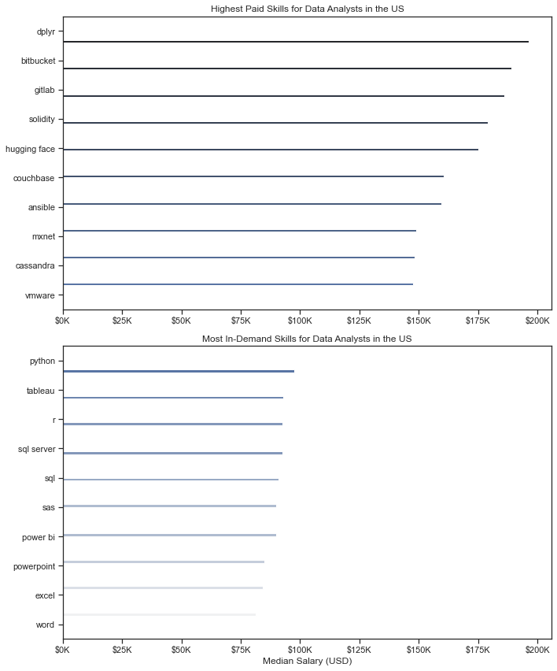

```python
# Increase figure size and adjust subplot layout
fig, ax = plt.subplots(2, 1, figsize=(10, 12))  # Adjust figsize as needed for larger size
sns.set_theme(style='ticks')

# Top 10 Highest Paid Skills for Data Analysts
sns.barplot(data=df_DA_top_pay, x='median', y=df_DA_top_pay.index, hue='median', ax=ax[0], palette='dark:b_r')
ax[0].legend().remove()
ax[0].set_title('Highest Paid Skills for Data Analysts in the US')
ax[0].set_ylabel('')
ax[0].set_xlabel('')
ax[0].xaxis.set_major_formatter(plt.FuncFormatter(lambda x, _: f'${int(x/1000)}K'))

# Top 10 Most In-Demand Skills for Data Analysts
sns.barplot(data=df_DA_skills, x='median', y=df_DA_skills.index, hue='median', ax=ax[1], palette='light:b')
ax[1].legend().remove()
ax[1].set_title('Most In-Demand Skills for Data Analysts in the US')
ax[1].set_ylabel('')
ax[1].set_xlabel('Median Salary (USD)')
ax[1].set_xlim(ax[0].get_xlim())  # Set the same x-axis limits as the first plot
ax[1].xaxis.set_major_formatter(plt.FuncFormatter(lambda x, _: f'${int(x/1000)}K'))

# Adjust spacing between subplots
plt.subplots_adjust(hspace=0.4)  # Increase or decrease hspace as needed

plt.tight_layout()
plt.show()
```

## 4. What are the most optimal skills to learn for Data Analysts?

To identify the most optimal skills to learn ( the ones that are the highest paid and highest in demand) I calculated the percent of skill demand and the median salary of these skills. To easily identify which are the most optimal skills to learn.

```python
df_DA_US = df[(df['job_title_short'] == 'Data Analyst') & (df['job_country'] == 'United States')].copy()

# Drop NaN values from the 'salary_year_avg' column for accurate visualization
df_DA_US = df_DA_US.dropna(subset=['salary_year_avg'])

df_DA_US_exploded = df_DA_US.explode('job_skills')

df_DA_US_exploded[['salary_year_avg', 'job_skills']].head(5)
```

|  | salary_year_avg | job_skills |
| --- | --- | --- |
| 109 | 89000.0 | python |
| 109 | 89000.0 | r |
| 109 | 89000.0 | alteryx |
| 109 | 89000.0 | tableau |
| 180 | 90250.0 | excel |

```python
# using df_DA find the count of skills and also the median salary for each skill
df_DA_skills = df_DA_US_exploded.groupby('job_skills')['salary_year_avg'].agg(['count', 'median']).sort_values(by='count', ascending=False)

df_DA_skills = df_DA_skills.rename(columns={'count': 'skill_count', 'median': 'median_salary'})

DA_job_count = len(df_DA_US)  # Find count of Data Analyst jobs in US with salary info

df_DA_skills['skill_percent'] = df_DA_skills['skill_count'] / DA_job_count * 100

df_DA_skills = df_DA_skills[df_DA_skills['skill_count'] > 0]

df_DA_skills
```

| job_skills | skill_count | median_salary | skill_percent |
| --- | --- | --- | --- |
| sql | 2508 | 91000.0 | 57.655172 |
| excel | 1808 | 84392.0 | 41.563218 |
| python | 1431 | 97500.0 | 32.896552 |
| tableau | 1364 | 92875.0 | 31.356322 |
| sas | 926 | 90000.0 | 21.287356 |
| ... | ... | ... | ... |
| couchbase | 1 | 160515.0 | 0.022989 |
| chainer | 1 | 100000.0 | 0.022989 |
| chef | 1 | 85000.0 | 0.022989 |
| cordova | 1 | 113269.5 | 0.022989 |
| node.js | 1 | 83500.0 | 0.022989 |

170 rows × 3 columns

```python
skill_limit = 5

df_DA_skills_high_demand = df_DA_skills[df_DA_skills['skill_percent'] > skill_limit]
```

```python
pip install adjustText
```

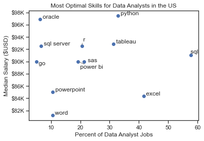

```python
from adjustText import adjust_text

plt.scatter(df_DA_skills_high_demand['skill_percent'], df_DA_skills_high_demand['median_salary'])
plt.xlabel('Percent of Data Analyst Jobs')
plt.ylabel('Median Salary ($USD)')  # Assuming this is the label you want for y-axis
plt.title('Most Optimal Skills for Data Analysts in the US')

# Get current axes, set limits, and format axes
ax = plt.gca()
ax.yaxis.set_major_formatter(plt.FuncFormatter(lambda y, pos: f'${int(y/1000)}K'))  # Example formatting y-axis

# Add labels to points and collect them in a list
texts = []
for i, txt in enumerate(df_DA_skills_high_demand.index):
    texts.append(plt.text(df_DA_skills_high_demand['skill_percent'].iloc[i], df_DA_skills_high_demand['median_salary'].iloc[i], " " + txt))

# Adjust text to avoid overlap and add arrows
adjust_text(texts, arrowprops=dict(arrowstyle='->', color='gray'))

plt.show()
```

## Visualizing Different Techonologies

Let's visualize the different technologies as well in the graph. We'll add color labels based on the technology (e.g., {Programming: Python})

```python
df_technology = df['job_type_skills'].copy()

# remove duplicates
df_technology = df_technology.drop_duplicates()

# remove NaN values
df_technology = df_technology.dropna()

# combine all dictionaries into one
technology_dict = {}
for row in df_technology:
    row_dict = ast.literal_eval(row)  # convert string to dictionary
    for key, value in row_dict.items():
        if key in technology_dict:  # if key already exists in technology_dict, add value to existing value
            technology_dict[key] += value
        else:                       # if key does not exist in technology_dict, add key and value
            technology_dict[key] = value

# remove duplicates by converting values to set then back to list
for key, value in technology_dict.items():
    technology_dict[key] = list(set(value))

technology_dict
```

```
{'analyst_tools': ['alteryx',
  'sheets',
  'sharepoint',
  'msaccess',
  'tableau',
  'nuix',
  'sap',
  'outlook',
  'dax',
  'spss',
  'powerpoint',
  'cognos',
  'word',
  'datarobot',
  'power bi',
  'qlik',
  'ssrs',
  'powerbi',
  'spreadsheet',
  'visio',
  'looker',
  'ssis',
  'esquisse',
  'excel',
  'sas',
  'splunk',
  'ms access',
  'microstrategy'],
 'programming': ['haskell',
  'mongodb',
  'sql',
  'lua',
  'elixir',
  'groovy',
  'f#',
  'lisp',
  'apl',
  'delphi',
  'cobol',
  'javascript',
```

[output cut: 201 more lines]

```
  'node.js',
  'ruby on rails',
  'symfony'],
 'sync': ['slack',
  'symphony',
  'google chat',
  'unify',
  'twilio',
  'microsoft teams',
  'rocketchat',
  'zoom',
  'mattermost',
  'wire',
  'ringcentral',
  'webex']}
```

```python
# turn dictionary into dataframe
df_technology = pd.DataFrame(list(technology_dict.items()), columns=['technology', 'skills'])

df_technology = df_technology.explode('skills')

df_technology
```

|  | technology | skills |
| --- | --- | --- |
| 0 | analyst_tools | alteryx |
| 0 | analyst_tools | sheets |
| 0 | analyst_tools | sharepoint |
| 0 | analyst_tools | msaccess |
| 0 | analyst_tools | tableau |
| ... | ... | ... |
| 9 | sync | zoom |
| 9 | sync | mattermost |
| 9 | sync | wire |
| 9 | sync | ringcentral |
| 9 | sync | webex |

256 rows × 2 columns

```python
# merge df_DA_skills and df_technology
df_DA_skills_tech = df_DA_skills.merge(df_technology, left_on='job_skills', right_on='skills')

df_DA_skills_tech
```

|  | skill_count | median_salary | skill_percent | technology | skills |
| --- | --- | --- | --- | --- | --- |
| 0 | 2508 | 91000.0 | 57.655172 | programming | sql |
| 1 | 1808 | 84392.0 | 41.563218 | analyst_tools | excel |
| 2 | 1431 | 97500.0 | 32.896552 | programming | python |
| 3 | 1364 | 92875.0 | 31.356322 | analyst_tools | tableau |
| 4 | 926 | 90000.0 | 21.287356 | analyst_tools | sas |
| ... | ... | ... | ... | ... | ... |
| 169 | 1 | 160515.0 | 0.022989 | databases | couchbase |
| 170 | 1 | 100000.0 | 0.022989 | libraries | chainer |
| 171 | 1 | 85000.0 | 0.022989 | other | chef |
| 172 | 1 | 113269.5 | 0.022989 | libraries | cordova |
| 173 | 1 | 83500.0 | 0.022989 | webframeworks | node.js |

174 rows × 5 columns

```python
df_DA_skills_tech_high_demand = df_DA_skills_tech[df_DA_skills_tech['skill_percent'] > skill_limit]
```

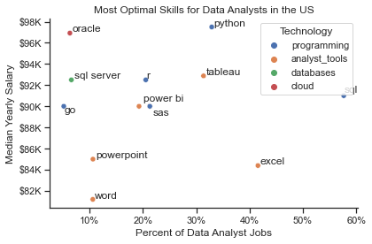

```python
sns.scatterplot(
    data=df_DA_skills_tech_high_demand,
    x='skill_percent',
    y='median_salary',
    hue='technology'
)

sns.despine()
sns.set_theme(style='ticks')

# Prepare texts for adjustText
texts = []
for i, txt in enumerate(df_DA_skills_high_demand.index):
    texts.append(plt.text(df_DA_skills_high_demand['skill_percent'].iloc[i], df_DA_skills_high_demand['median_salary'].iloc[i], txt))

# Adjust text to avoid overlap
adjust_text(texts, arrowprops=dict(arrowstyle='->', color='gray'))

# Set axis labels, title, and legend
plt.xlabel('Percent of Data Analyst Jobs')
plt.ylabel('Median Yearly Salary')
plt.title('Most Optimal Skills for Data Analysts in the US')
plt.legend(title='Technology')

from matplotlib.ticker import PercentFormatter
ax = plt.gca()
ax.yaxis.set_major_formatter(plt.FuncFormatter(lambda y, pos: f'${int(y/1000)}K'))
ax.xaxis.set_major_formatter(PercentFormatter(decimals=0))

# Adjust layout and display plot
plt.tight_layout()
plt.show()
```